# Regression Models Course Project

Han Yunxi

18 February 2015

## Executive Summary

*Motor Trend*, a magazine about the automobile industry, are interested in exploring the relationship between a set of automobile variables and miles per gallon *(mpg)*. They are particularly interested in the following two questions:

Is an automatic or manual transmission better for MPG?

Quantify the MPG difference between automatic and manual transmissions.

## Exploratory Data Analysis (EDA)

From the `?mtcars` help file, we see that the dataset comprises fuel consumption *(outcome)* and 10 aspects *(predictors)* of automobile design and performance for 32 automobiles (1973–74 models).

```r
library(ggplot2)
library(data.table)
library(knitr)
data(mtcars)
```

#### EDA Findings

A scatterplot matrix of *mpg* and other 10 predictors is generated. The top row shows the relationship between *mpg* and each of the predictors. From the scatterplot, there appears to be some relationship between *mpg* and *disp* , *hp*, *wt*. There are a great deal of random variables present in other predictors. In other words, the model is likely to consist of *disp* , *hp* and *wt*. This requires further investigation.

## Statistical Inference

Here, we calculate the 95% confidence intervals on *mpg* for automatic and manual cars. A t-test is used to evaluate the if there is no difference in average *mpg* between automatic($\mu_0$) and manual($\mu_a$) cars at 95% confidence interval.

$H_0$ : $\mu_0$ = $\mu_a$

$H_a$ : $\mu_0$ < $\mu_a$

```r
  t <- t.test(mpg ~ am, data = mtcars, alternative = c("less"),paired=FALSE, conf.level = 0.95)
  t
```

```
##
##  Welch Two Sample t-test
##
## data:  mpg by am
## t = -3.7671, df = 18.332, p-value = 0.0006868
## alternative hypothesis: true difference in means is less than 0
## 95 percent confidence interval:
##       -Inf -3.913256
## sample estimates:
## mean in group 0 mean in group 1
##        17.14737        24.39231
```

From the results, we see that manual cars average 24.4 *mpg*, automatic cars average 17.1 *mpg*. Since the p-value, 0.0006 is lesser than 0.05, we reject $H_0$ and conclude that manual cars have a better average *mpg* than automatic cars.

## Multiple Regression

```r
fit_EDA <- lm(mpg ~ disp + hp + wt, data = mtcars)  #model 1
fit_Full <- lm(mpg ~ ., data=mtcars)  # model 2
fit_Stepwise <- step(lm(mpg ~ ., data=mtcars)) # model 3
```

#### Model 0

Using the EDA results, we fit *mpg ~ disp + hp + wt and test if it is a good fit. The adjusted $R^2$ is 0.8. So about 80% of the variation in the scores can be predicted using the model. Let’s see if the model can be improved further

#### Model 1

The table below shows the adjusted $R^2$ is also 0.8. Similar to Model 0, about 80% of the variation in the scores can be predicted using the model.

```r
summary(fit_Full)
```

```
##
## Call:
## lm(formula = mpg ~ ., data = mtcars)
##
## Residuals:
##     Min      1Q  Median      3Q     Max
## -3.4506 -1.6044 -0.1196  1.2193  4.6271
##
## Coefficients:
##             Estimate Std. Error t value Pr(>|t|)
## (Intercept) 12.30337   18.71788   0.657   0.5181
## cyl         -0.11144    1.04502  -0.107   0.9161
## disp         0.01334    0.01786   0.747   0.4635
## hp          -0.02148    0.02177  -0.987   0.3350
## drat         0.78711    1.63537   0.481   0.6353
## wt          -3.71530    1.89441  -1.961   0.0633 .
## qsec         0.82104    0.73084   1.123   0.2739
## vs           0.31776    2.10451   0.151   0.8814
## am           2.52023    2.05665   1.225   0.2340
## gear         0.65541    1.49326   0.439   0.6652
## carb        -0.19942    0.82875  -0.241   0.8122
## ---
## Signif. codes:  0 '***' 0.001 '**' 0.01 '*' 0.05 '.' 0.1 ' ' 1
##
## Residual standard error: 2.65 on 21 degrees of freedom
## Multiple R-squared:  0.869,  Adjusted R-squared:  0.8066
## F-statistic: 13.93 on 10 and 21 DF,  p-value: 3.793e-07
```

```r
summary(fit_EDA)
```

```
##
## Call:
## lm(formula = mpg ~ disp + hp + wt, data = mtcars)
##
## Residuals:
##    Min     1Q Median     3Q    Max
## -3.891 -1.640 -0.172  1.061  5.861
##
## Coefficients:
##              Estimate Std. Error t value Pr(>|t|)
## (Intercept) 37.105505   2.110815  17.579  < 2e-16 ***
## disp        -0.000937   0.010350  -0.091  0.92851
## hp          -0.031157   0.011436  -2.724  0.01097 *
## wt          -3.800891   1.066191  -3.565  0.00133 **
## ---
## Signif. codes:  0 '***' 0.001 '**' 0.01 '*' 0.05 '.' 0.1 ' ' 1
##
## Residual standard error: 2.639 on 28 degrees of freedom
## Multiple R-squared:  0.8268, Adjusted R-squared:  0.8083
## F-statistic: 44.57 on 3 and 28 DF,  p-value: 8.65e-11
```

#### Model 2

The table below shows that adjusted R-squared value 0.83 - an improvement of 3% over the full model. P-values are also significant at 95%. This model *mpg = wt + qsec + am* seems to be a good fit.

```r
summary(fit_Stepwise)
```

```
##
## Call:
## lm(formula = mpg ~ wt + qsec + am, data = mtcars)
##
## Residuals:
##     Min      1Q  Median      3Q     Max
## -3.4811 -1.5555 -0.7257  1.4110  4.6610
##
## Coefficients:
##             Estimate Std. Error t value Pr(>|t|)
## (Intercept)   9.6178     6.9596   1.382 0.177915
## wt           -3.9165     0.7112  -5.507 6.95e-06 ***
## qsec          1.2259     0.2887   4.247 0.000216 ***
## am            2.9358     1.4109   2.081 0.046716 *
## ---
## Signif. codes:  0 '***' 0.001 '**' 0.01 '*' 0.05 '.' 0.1 ' ' 1
##
## Residual standard error: 2.459 on 28 degrees of freedom
## Multiple R-squared:  0.8497, Adjusted R-squared:  0.8336
## F-statistic: 52.75 on 3 and 28 DF,  p-value: 1.21e-11
```

### Interactions

```r
fit_Interaction <- lm(mpg ~ wt + qsec + am + qsec*am , data = mtcars) # model 4
summary(fit_Interaction)
```

```
##
## Call:
## lm(formula = mpg ~ wt + qsec + am + qsec * am, data = mtcars)
##
## Residuals:
##     Min      1Q  Median      3Q     Max
## -4.2822 -1.5572 -0.2782  1.1654  4.1293
##
## Coefficients:
##             Estimate Std. Error t value Pr(>|t|)
## (Intercept)  16.5290     7.2671   2.275   0.0311 *
## wt           -3.7772     0.6711  -5.629 5.66e-06 ***
## qsec          0.8169     0.3299   2.477   0.0198 *
## am          -15.6137     8.6237  -1.811   0.0814 .
## qsec:am       1.0600     0.4870   2.177   0.0384 *
## ---
## Signif. codes:  0 '***' 0.001 '**' 0.01 '*' 0.05 '.' 0.1 ' ' 1
##
## Residual standard error: 2.309 on 27 degrees of freedom
## Multiple R-squared:  0.8721, Adjusted R-squared:  0.8532
## F-statistic: 46.03 on 4 and 27 DF,  p-value: 1.119e-11
```

### Residual Diagnostics

```r
  y <- mtcars$mpg; x <- mtcars$am; n <- length(y)
  fit <- lm(y ~ x)
  e <- resid(fit)
  yhat <- predict(fit)
  max(abs(e -(y - yhat)))
```

```
## [1] 4.840572e-14
```

## Appendix

```r
# use the booktabs package
kable(mtcars, format = "latex", booktabs = TRUE)
```

[output not shown]

```r
# R Markdown/Github Markdown tables
# kable(head(mtcars[, 1:5]), format = "markdown")
```

### Exploratory Data Analysis

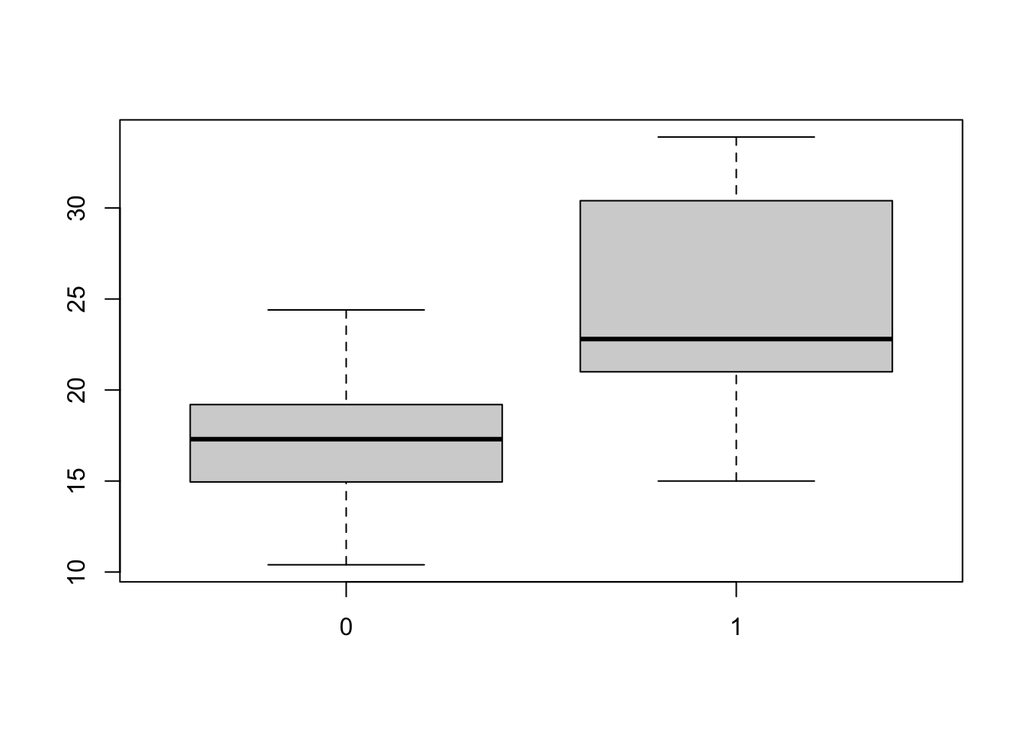

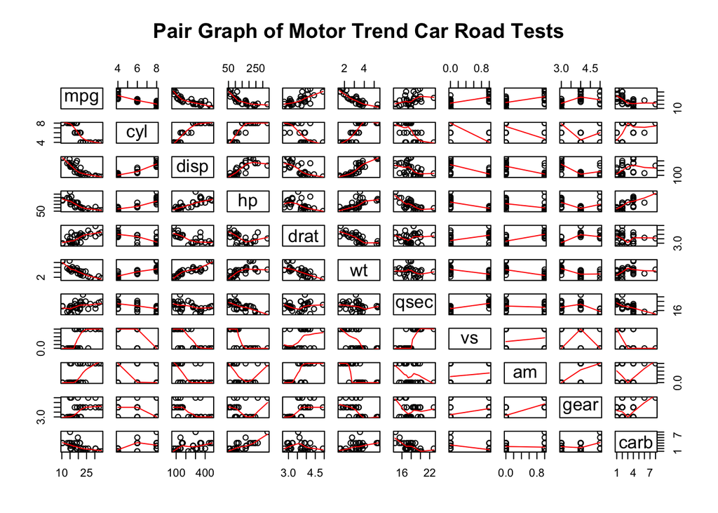